# Aula 3

## Selecionando os dados

Para selecionar os dados é importante saber o nome das colunas, uma vez que nosso dados está disposto em forma tabular, on de as variáveis estão dispostas em colunas.

Para isto usamos:

```r
colnames(ai_df)
```

```
 [1] "FID"        "ogc_fid"    "vw_num_aut" "numero_ai"  "serie"
 [6] "origem"     "tipo"       "valor_mult" "embargo"    "apreensao"
[11] "autuado"    "cpf_cnpj"   "desc_ai"    "desc_sanc"  "data"
[16] "ano"        "artigo_1"   "artigo_2"   "tipo_infra" "nome_uc"
[21] "cnuc"       "municipio"  "uf"         "termos_emb" "termos_apr"
[26] "ordem_fisc" "processo"   "julgamento" "the_geom"
```

E a estrutura que tem os dados:

```r
str(ai_df)
```

```
spc_tbl_ [35,837 × 29] (S3: spec_tbl_df/tbl_df/tbl/data.frame)
 $ FID       : chr [1:35837] "autos_infracao_icmbio.1" "autos_infracao_icmbio.2" "autos_infracao_icmbio.3" "autos_infracao_icmbio.4" ...
 $ ogc_fid   : int [1:35837] 1 2 3 4 5 6 7 8 9 10 ...
 $ vw_num_aut: int [1:35837] 1 2 3 4 5 6 7 8 9 10 ...
 $ numero_ai : chr [1:35837] "004TY6C1" "009Z5YHU" "00EZFFO7" "00GXXMSY" ...
 $ serie     : chr [1:35837] NA NA NA NA ...
 $ origem    : chr [1:35837] "Eletrônico" "Eletrônico" "Eletrônico" "Eletrônico" ...
 $ tipo      : chr [1:35837] "Multa Simples" "Multa Simples" "Multa Simples" "Multa Simples" ...
 $ valor_mult: num [1:35837] 33150 500 28000 445000 3520 ...
 $ embargo   : chr [1:35837] "Sim" "Não" "Não" "Sim" ...
 $ apreensao : chr [1:35837] "Não" "Não" "Não" "Não" ...
 $ autuado   : chr [1:35837] "EDINALDO OLIVEIRA SANTOS" "Luiz Oscar Marques Ferreira" "ODAIR JOSÉ TAVARES DE SOUZA" "WANDERLEY TAVARES AMORIM" ...
 $ cpf_cnpj  : chr [1:35837] "39667227553" "30989388115" "72661550291" "18370268234" ...
 $ desc_ai   : chr [1:35837] "Instalar criação de suínos, atividade sujeita ao licenciamento ambiental, no Parque Nacional da Serra de Itabai"| __truncated__ NA "Fazer uso de fogo dentro da Unidade de Conservação Reserva Extrativista Chico Mendes sem autorização do órgão c"| __truncated__ "Difilcuta…
 $ desc_sanc : chr [1:35837] NA NA NA NA ...
 $ data      : Date[1:35837], format: "2022-09-20" "2020-10-13" ...
 $ ano       : int [1:35837] 2022 2020 2023 2022 2022 2023 2023 2023 2023 2022 ...
 $ artigo_1  : int [1:35837] 66 90 58 48 35 54 66 50 92 24 ...
 $ artigo_2  : int [1:35837] 0 0 93 0 93 0 93 93 0 93 ...
 $ tipo_infra: chr [1:35837] "Das Infrações Relativas à Poluição e outras Infrações Ambientais" "Das Infrações Cometidas Exclusivamente em Unidades de Conservação" "Das Infrações Contra a Flora" "Das Infrações Contra a Flora" ...
 $ nome_uc   : chr [1:35837] "PARNA Serra de Itabaiana" "PARNA da Chapada Diamantina" "RESEX Chico Mendes" "ESEC da Terra do Meio" ...
 $ cnuc      : chr [1:35837] "0000.00.0147" "0000.00.0137" "0000.00.0222" "0000.00.0047" ...
 $ municipio : chr [1:35837] "Areia Branca" "Palmeiras" "Brasiléia" "Altamira" ...
 $ uf        : chr [1:35837] "SE" "BA" "AC" "PA" ...
 $ termos_emb: chr [1:35837] "6DWOLONQ" NA NA "Z5WMBTX6" ...
 $ termos_apr: chr [1:35837] NA NA NA NA ...
 $ ordem_fisc: chr [1:35837] "SE027235" "DF593605" "AC017876" "DF594642" ...
 $ processo  : chr [1:35837] "02124003406202297" "02125000946202047" "02119002691202389" "02121002614202207" ...
 $ julgamento: chr [1:35837] NA NA NA NA ...
 $ the_geom  : chr [1:35837] "MULTIPOINT ((-37.40192777777778 -10.83557777777778))" "MULTIPOINT ((-41.51638799999999 -12.605834))" "MULTIPOINT ((-69.03551277777778 -10.64926222222222))" "MULTIPOINT ((-53.96003611111112 -6.29975833333333))" ...
 - attr(*, "spec")=
  .. cols(
  ..   FID = col_character(),
  ..   ogc_fid = col_integer(),
  ..   vw_num_aut = col_integer(),
  ..   numero_ai = col_character(),
  ..   serie = col_character(),
  ..   origem = col_character(),
  ..   tipo = col_character(),
  ..   valor_mult = col_double(),
```

[output cut: 8 more lines]

```
  ..   artigo_1 = col_integer(),
  ..   artigo_2 = col_integer(),
  ..   tipo_infra = col_character(),
  ..   nome_uc = col_character(),
  ..   cnuc = col_character(),
  ..   municipio = col_character(),
  ..   uf = col_character(),
  ..   termos_emb = col_character(),
  ..   termos_apr = col_character(),
  ..   ordem_fisc = col_character(),
  ..   processo = col_character(),
  ..   julgamento = col_character(),
  ..   the_geom = col_character()
  .. )
 - attr(*, "problems")=<externalptr>
```

Para entender os intervalos de variação dos dados podemos usar outra função de sumário, o *skim()*

Outra forma de sumarizar os dados:

```r
#library(skimr)
skim(ai_df)
```

```
── Data Summary ────────────────────────
                           Values
Name                       ai_df
Number of rows             35837
Number of columns          29
_______________________
Column type frequency:
  character                22
  Date                     1
  numeric                  6
________________________
Group variables            None
```

|  | skim_variable | n_missing | complete_rate | min | max | empty | n_unique | whitespace |
| --- | --- | --- | --- | --- | --- | --- | --- | --- |
| 1 | FID | 0 | 1.00000000 | 23 | 27 | 0 | 35837 | 0 |
| 2 | numero_ai | 0 | 1.00000000 | 6 | 8 | 0 | 31744 | 0 |
| 3 | serie | 10801 | 0.69860758 | 1 | 1 | 0 | 2 | 0 |
| 4 | origem | 0 | 1.00000000 | 5 | 10 | 0 | 2 | 0 |
| 5 | tipo | 0 | 1.00000000 | 7 | 46 | 0 | 40 | 0 |
| 6 | embargo | 0 | 1.00000000 | 3 | 3 | 0 | 2 | 0 |
| 7 | apreensao | 0 | 1.00000000 | 3 | 3 | 0 | 2 | 0 |
| 8 | autuado | 1 | 0.99997210 | 1 | 86 | 0 | 27726 | 0 |
| 9 | cpf_cnpj | 4561 | 0.87272930 | 1 | 16 | 0 | 24509 | 0 |
| 10 | desc_ai | 194 | 0.99458660 | 1 | 254 | 0 | 31617 | 0 |

[output cut: 12 more lines]

|  | skim_variable | n_missing | complete_rate | min | max | median | n_unique |
| --- | --- | --- | --- | --- | --- | --- | --- |
| 1 | data | 33 | 0.9990792 | 215-11-11 | 2024-09-02 | 2017-07-06 | 5104 |

|  | skim_variable | n_missing | complete_rate | mean | sd | p0 | p25 | p50 | p75 | p100 | hist |
| --- | --- | --- | --- | --- | --- | --- | --- | --- | --- | --- | --- |
| 1 | ogc_fid | 0 | 1.0000000 | 17919.00000 | 1.034540e+04 | 1 | 8960 | 17919 | 26878 | 35837 | ▇▇▇▇▇ |
| 2 | vw_num_aut | 0 | 1.0000000 | 18409.42252 | 1.060321e+04 | 1 | 8960 | 18621 | 27580 | 36539 | ▇▇▇▇▇ |
| 3 | valor_mult | 0 | 1.0000000 | 154895.89401 | 1.346058e+06 | 0 | 1010 | 5000 | 20000 | 86385000 | ▇▁▁▁▁ |
| 4 | ano | 33 | 0.9990792 | 2016.73293 | 1.055231e+01 | 215 | 2013 | 2017 | 2021 | 2024 | ▁▁▁▁▇ |
| 5 | artigo_1 | 0 | 1.0000000 | 58.55465 | 2.381217e+01 | 0 | 35 | 50 | 90 | 93 | ▁▇▇▃▇ |
| 6 | artigo_2 | 6052 | 0.8311243 | 55.39537 | 4.565846e+01 | 0 | 0 | 93 | 93 | 225 | ▆▁▇▁▁ |

Com a função subset() podemos ‘recortar’ ou ‘filtrar’ os dados:

```r
ai_c_embargo <- subset(ai_df, embargo=="Sim" & valor_mult<=25000, select = c("numero_ai","valor_mult","ano" ))
ai_s_embargo <- subset(ai_df, embargo=="Não" & valor_mult<=25000, select = c("numero_ai","valor_mult","ano" ))
```

Visualizando o resultado do subconjunto de dados:

[figure not shown]

```r
par(mfrow=c(1,2))
hist(ai_c_embargo$valor_mult, main = "Com embargo", xlab = "multa (R$)")
hist(ai_s_embargo$valor_mult, main = "Sem embargo", xlab = "multa (R$)")
```

Cria um DF temporário:

```r
ai_tmp$embargo <- ai_df$embargo == "Sim"
```

[output not shown]

## Alterando o DF

Adiciona uma nova coluna ‘embargos’ mas com resultado lógico:

```r
ai_tmp$embargo <- ai_df$embargo == "Sim"
```

[output not shown]

Visualizando as primeiras linhas:

[output not shown]

Histograma dos valores de multas:

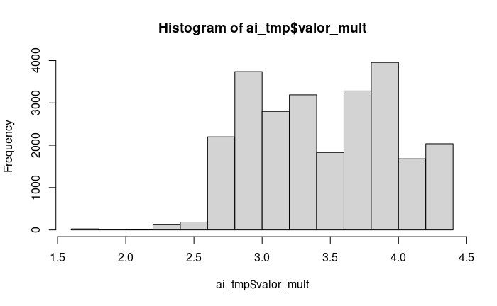

Agora isualizando o resultado do subconjunto de dados:

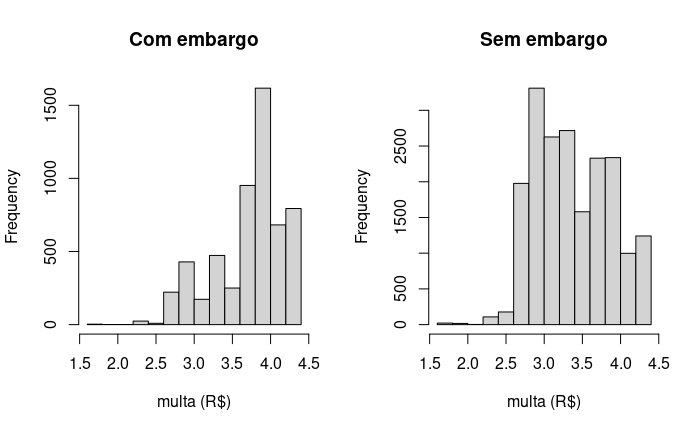

```r
par(mfrow=c(1,2))
hist(ai_tmp$valor_mult[ai_tmp$embargo], main = "Com embargo", xlab = "multa (R$)")
hist(ai_tmp$valor_mult[ai_tmp$embargo==FALSE], main = "Sem embargo", xlab = "multa (R$)")
```